# Lung Cancer and Poverty in the American Midwest

Chris Brodsky

# Results

The data inference and graph below illustrate the relationship between lung cancer rates and poverty in Midwestern states. That the confidence interval values for “poverty” are both positive indicates a statistically significant relationship between rates of lung cancer among men over the age of 18 and the percentage of households below the poverty line. The chart below illustrates this relationship graphically. The blue line of best fit indicates a clear linear relationship between rising poverty and lung cancer rates.

```
##
## Call:
## lm_basic(formula = lung ~ 1 + poverty, data = cancer_mw)
##
## Residuals:
##     Min      1Q  Median      3Q     Max
## -34.262  -8.183  -0.316   7.805  32.367
##
## Coefficients:
##             Estimate    5 %   95 %
## (Intercept)   50.103 47.124 53.082
## poverty        1.386  1.186  1.586
##
## Residual standard error: 12.28 on 502 degrees of freedom
## Multiple R-squared:  0.2058, Adjusted R-squared:  0.2042
## F-statistic:   130 on 1 and 502 DF,  p-value: < 2.2e-16
```

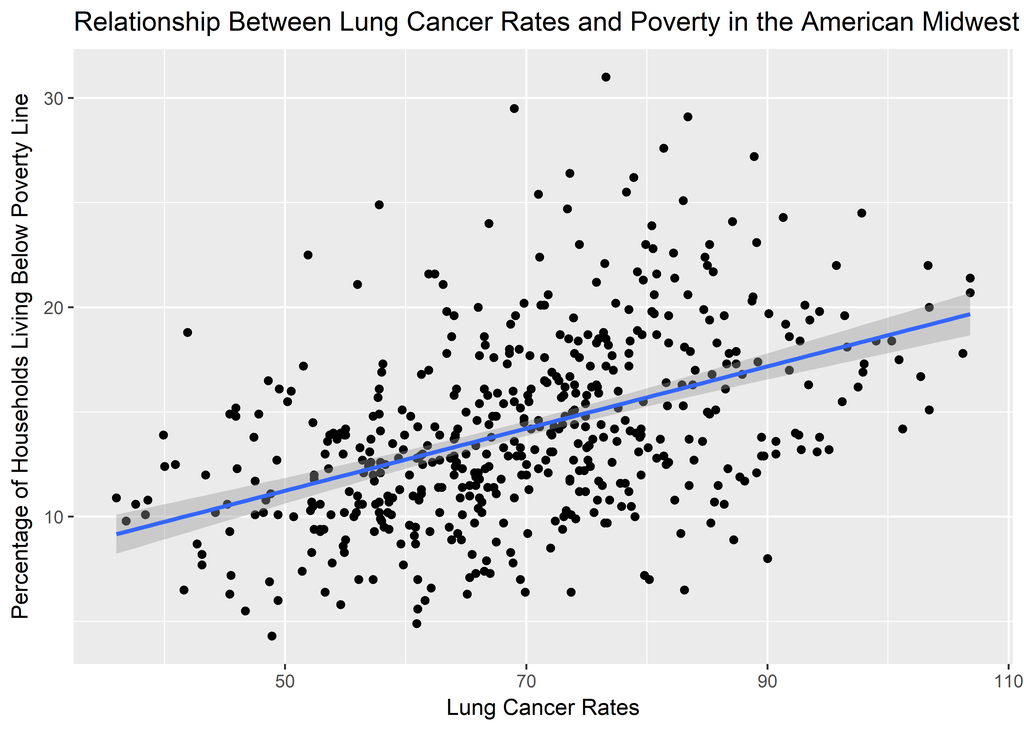

```
##
## Call:
## lm_basic(formula = poverty ~ 1 + black_alone, data = cancer_mw)
##
## Residuals:
##     Min      1Q  Median      3Q     Max
## -9.2442 -2.7123 -0.5519  2.3611 17.0376
##
## Coefficients:
##             Estimate     5 %   95 %
## (Intercept)  13.3039 12.9340 13.674
## black_alone   0.2664  0.2069  0.326
##
## Residual standard error: 4.282 on 502 degrees of freedom
## Multiple R-squared:  0.09788,    Adjusted R-squared:  0.09609
## F-statistic: 54.47 on 1 and 502 DF,  p-value: 6.597e-13
```

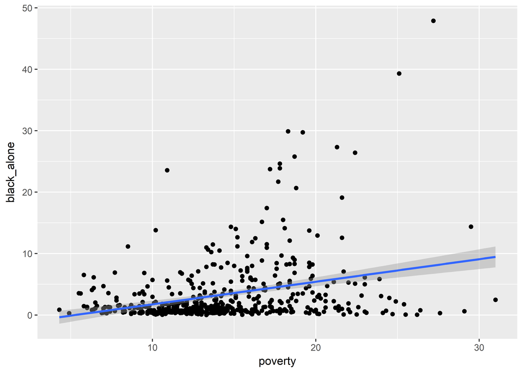

The map below illustrates the prevalence of lung cancer rates in the Midwest according to colored dots. As the map shows, the areas with the highest rates of lung cancer are concentrated in southeastern Missouri and southwestern Illinois. According to data from the Missouri Community Action Network, the poorest counties in Missouri are concentrated almost entirely in this area with several outlier counties dispersed throughout the state. Data from the Heartland Alliance shows a similar dynamic in southwestern Illinois. Poverty rates are concentrated in the southwestern counties of the state. The cross-border region spanning southeast and southwest Illinois and Missouri respectively suffers from the highest rates of poverty in both states. This data reflects the inferences shown above as well as the map below highlighting the overlap between concentrations of lung cancer and poverty.

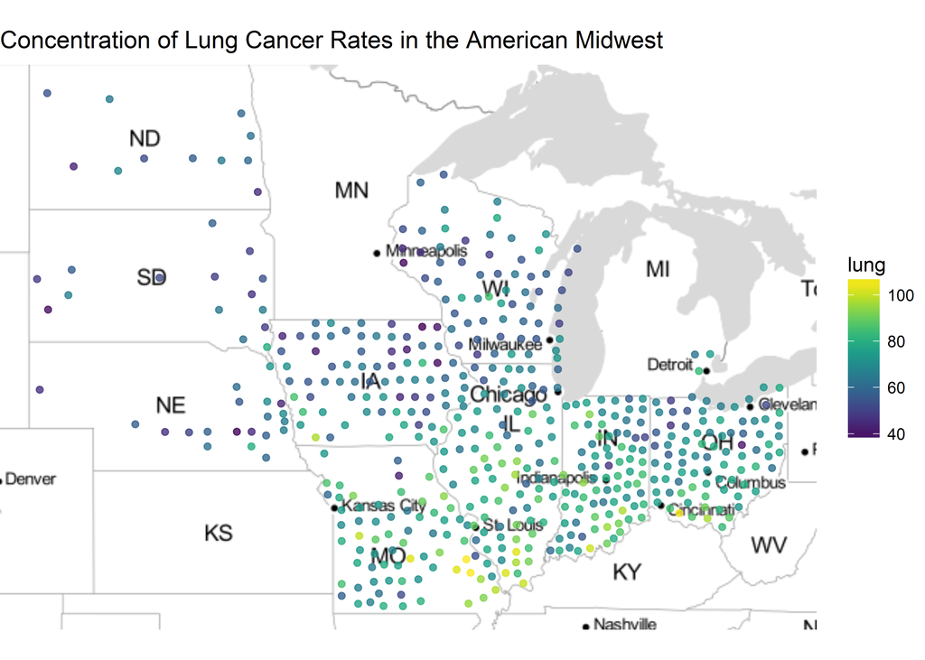

## Conclusion

The data show clear relationships between poverty and lung cancer rates in the American Midwest and between poverty and race. These dynamics highlight the complexity of national health issues and their overlapping factors. As policymakers seek to tackle economic growth in the form of a revitalized manufacturing sector, they might also consider unintended side effects on national health, poverty, and racial dynamics. This is especially important considering the current opioid crisis which is consuming valuable time and energy from policymakers, not to mention lives lost. Ultimately, this analysis serves to highlight the degree of overlap among major policy concerns affecting the daily lives of millions of Americans in the Midwest. The data examines a case-study of statistically significant relationships in the Midwest although the results are likely relevant and replicable in states and counties around the world.

## References

http://www.areadevelopment.com/RegionalReports/Q1-2013/states-leading-US-manufacturing-resurgence-2665542.shtml http://www.lung.org/about-us/blog/2016/06/lung-cancer-and-pollution.html http://action.heartlandalliance.org/site/MessageViewer?em_id=10361.0 http://www.communityaction.org/missouri-poverty-facts/